# Visualizing Carbon Dioxide Levels

Jose Luis Diaz Pulgar

2023-03-24

### Visualizing Carbon Dioxide Levels

These data are calculated by analyzing ice cores. Over time, gas gets trapped in the ice of Antarctica. Scientists can take samples of that ice and see how much carbon is in it. The deeper you go into the ice, the farther back in time you can analyze!

- The first dataset comes from World Data Center for Paleoclimatology, Boulder and NOAA Paleoclimatology Program and describes the carbon dioxide levels back thousands of years “Before Present” (BP) or before January 1, 1950.
- The second dataset explores carbon dioxide starting at year zero up until the recent year of 2014. This dataset was compiled by the Institute for Atmospheric and Climate Science (IAC) at Eidgenössische Technische Hochschule in Zürich, Switzerland.

In order to understand the information in these datasets, it’s important to understand two key facts about the data:

The metric for carbon dioxide level is measured as parts per million or CO2 ppmv. This number describes the number of carbon dioxide molecules per one million gas molecules in our atmosphere.

The second metric describes years before present, which is “a time scale used mainly in … scientific disciplines to specify when events occurred in the past… standard practice is to use 1 January 1950 as the commencement date of the age scale, reflecting the origin of practical radiocarbon dating in the 1950s. The abbreviation “BP” has alternatively been interpreted as “Before Physics” that is, before nuclear weapons testing artificially altered the proportion of the carbon isotopes in the atmosphere, making dating after that time likely to be unreliable.” This means that saying “the year 20 BP” would be the equivalent of saying “The year 1930.”

#### Loading Libraries needed.

#### Load the CSV file and inspect the first 10 rows.

```r
# load libraries and data
library(readr)
library(dplyr)
library(ggplot2)

noaa_data <- read.csv("Carbon_dioxide_levels.csv")

head(noaa_data,10)
```

|  | Age_yrBP | CO2_ppmv |
| --- | --- | --- |
| 1 | 137 | 280.4 |
| 2 | 268 | 274.9 |
| 3 | 279 | 277.9 |
| 4 | 395 | 279.1 |
| 5 | 404 | 281.9 |
| 6 | 485 | 277.7 |
| 7 | 559 | 281.1 |
| 8 | 672 | 282.2 |
| 9 | 754 | 280.1 |
| 10 | 877 | 278.4 |

#### Visualizing data

[figure not shown]

```r
options(scipen=10000) #removes scientific notation

noaa_viz <- ggplot(data=noaa_data, aes(x=Age_yrBP, y=CO2_ppmv))+
  geom_line(color="blue")+
  labs(title = "Carbon Dioxide Levels From 8,000 to 136 Years BP", subtitle = "From World Data Center for Paleoclimatology and NOAA Paleoclimatology Program", x="Years Before Today (0=1950)", y = "Carbon Dioxide Level (Parts Per Million)")+
  scale_x_reverse(lim=c(800000,0))
noaa_viz
```

#### Loading second dataset

```r
iac_data <- read.csv("Yearly_CO2.csv")

head(iac_data,10)
```

|  | year | data_mean_global | data_mean_nh | data_mean_sh |
| --- | --- | --- | --- | --- |
| 1 | 0 | 277.454 | 277.454 | 277.454 |
| 2 | 1 | 277.137 | 277.137 | 277.137 |
| 3 | 2 | 277.160 | 277.160 | 277.160 |
| 4 | 3 | 277.158 | 277.158 | 277.158 |
| 5 | 4 | 277.157 | 277.157 | 277.157 |
| 6 | 5 | 277.167 | 277.167 | 277.167 |
| 7 | 6 | 277.172 | 277.172 | 277.172 |
| 8 | 7 | 277.171 | 277.171 | 277.171 |
| 9 | 8 | 277.175 | 277.175 | 277.175 |
| 10 | 9 | 277.176 | 277.176 | 277.176 |

#### Visualizing data

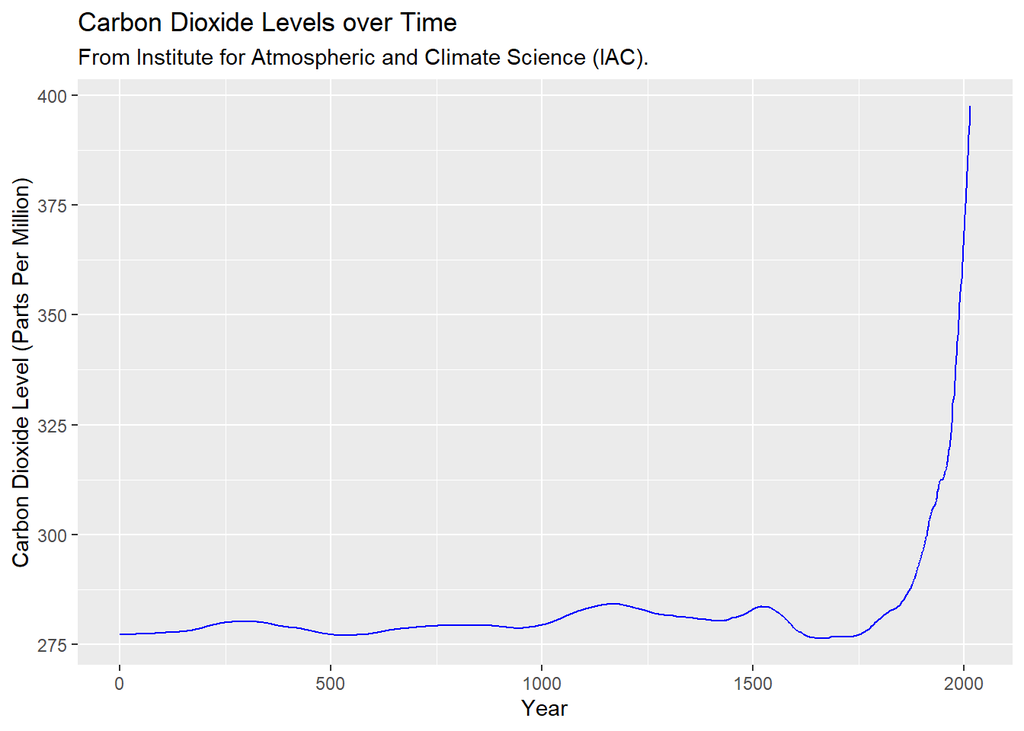

```r
#Create IAC Visualization

iac_viz <- ggplot(data=iac_data, aes(x=year, y=data_mean_global))+
  geom_line(color="blue")+
  labs(title = "Carbon Dioxide Levels over Time", subtitle = "From Institute for Atmospheric and Climate Science (IAC).", x="Year", y = "Carbon Dioxide Level (Parts Per Million)")
iac_viz
```

#### Comparing with co2 peak level before 1950

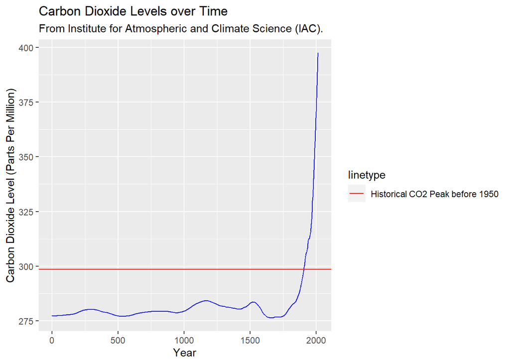

```r
#Create IAC Visualization

millennia_max <- max(noaa_data$CO2_ppmv)

iac_viz + geom_hline(aes(yintercept = millennia_max, linetype="Historical CO2 Peak before 1950"), color="red")
```